# Non-linear latent variable models and error-in-variable models

Klaus Kähler Holst

2025-01-11

```r
library('lava')
```

We consider the measurement models given by

$$X_{j} = \eta_{1} + \epsilon_{j}^{x},
\quad j=1,2,3$$
$$Y_{j} = \eta_{2} +
\epsilon_{j}^{y}, \quad j=1,2,3$$
and with a structural model given by
$$\eta_{2} = f(\eta_{1}) + Z +
\zeta_{2}\label{ex:eta2}$$
$$\eta_{1}
= Z + \zeta_{1}\label{ex:eta1}$$
with iid measurement errors $\epsilon_{j}^{x},\epsilon_{j}^{y},\zeta_{1},\zeta_{2}\sim\mathcal{N}(0,1), j=1,2,3.$ and standard normal distributed covariate $Z$. To simulate from this model we use the following syntax:

```r
f <- function(x) cos(1.25*x) + x - 0.25*x^2
m <- lvm(x1+x2+x3 ~ eta1, y1+y2+y3 ~ eta2, latent=~eta1+eta2)
regression(m) <- eta1+eta2 ~ z
functional(m, eta2~eta1) <- f

d <- sim(m, n=200, seed=42) # Default is all parameters are 1
```

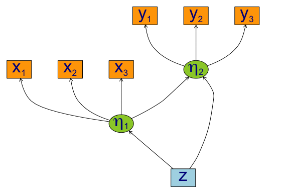

```r
## plot(m, plot.engine="visNetwork")
plot(m)
```

We refer to (K. K. Holst and Budtz-Jørgensen 2013) for details on the syntax for model specification.

# Estimation

To estimate the parameters using the two-stage estimator described in (Klaus Kähler Holst and Budtz-Jørgensen 2020), the first step is now to specify the measurement models

```r
m1 <- lvm(x1+x2+x3 ~ eta1, eta1 ~ z, latent=~eta1)
m2 <- lvm(y1+y2+y3 ~ eta2, eta2 ~ z, latent=~eta2)
```

Next, we specify a quadratic relationship between the two latent variables

```r
nonlinear(m2, type="quadratic") <- eta2 ~ eta1
```

and the model can then be estimated using the two-stage estimator

```r
e1 <- twostage(m1, m2, data=d)
e1
```

```
#>                     Estimate Std. Error Z-value  P-value
#> Measurements:
#>    y2~eta2             0.977      0.035  28.309   <1e-12
#>    y3~eta2             1.045      0.035  29.982   <1e-12
#> Regressions:
#>    eta2~z              0.885      0.208   4.260    2e-05
#>    eta2~eta1_1         1.141      0.174   6.552  5.7e-11
#>    eta2~eta1_2        -0.451      0.072  -6.292  3.1e-10
#> Intercepts:
#>    y2                 -0.122      0.109  -1.117     0.26
#>    y3                 -0.099      0.105  -0.937     0.35
#>    eta2                0.678      0.174   3.906  9.4e-05
#> Residual Variances:
#>    y1                  1.307      0.177   7.368
#>    y2                  1.111      0.145   7.671
#>    y3                  0.810      0.132   6.132
#>    eta2                2.085      0.290   7.193
```

We see a clear statistically significant effect of the second order term (`eta2~eta1_2`). For comparison we can also estimate the full MLE of the linear model:

```r
e0 <- estimate(regression(m1%++%m2, eta2~eta1), d)
estimate(e0,keep="^eta2~[a-z]",regex=TRUE) ## Extract coef. matching reg.ex.
```

```
#>           Estimate Std.Err    2.5% 97.5%   P-value
#> eta2~eta1   1.4140  0.2261 0.97083 1.857 4.014e-10
#> eta2~z      0.6374  0.2778 0.09291 1.182 2.177e-02
```

Next, we calculate predictions from the quadratic model using the estimated parameter coefficients
$$\mathbb{E}_{\widehat{\theta}_{2}}(\eta_{2} \mid \eta_{1}, Z=0),$$

```r
newd <- expand.grid(eta1=seq(-4, 4, by=0.1), z=0)
pred1 <- predict(e1, newdata=newd, x=TRUE)
head(pred1)
```

```
#>           y1      y2      y3    eta2
#> [1,] -11.094 -10.959 -11.690 -11.094
#> [2,] -10.624 -10.500 -11.199 -10.624
#> [3,] -10.163 -10.049 -10.717 -10.163
#> [4,]  -9.711  -9.608 -10.245  -9.711
#> [5,]  -9.268  -9.175  -9.782  -9.268
#> [6,]  -8.834  -8.751  -9.329  -8.834
```

To obtain a potential better fit we next proceed with a natural cubic spline

```r
kn <- seq(-3,3,length.out=5)
nonlinear(m2, type="spline", knots=kn) <- eta2 ~ eta1
e2 <- twostage(m1, m2, data=d)
e2
```

```
#>                     Estimate Std. Error Z-value  P-value
#> Measurements:
#>    y2~eta2             0.978      0.035  28.313   <1e-12
#>    y3~eta2             1.045      0.035  29.971   <1e-12
#> Regressions:
#>    eta2~z              0.867      0.203   4.278  1.9e-05
#>    eta2~eta1_1         2.862      0.673   4.255  2.1e-05
#>    eta2~eta1_2         0.003      0.101   0.034     0.97
#>    eta2~eta1_3        -0.263      0.294  -0.894     0.37
#>    eta2~eta1_4         0.508      0.352   1.443     0.15
#> Intercepts:
#>    y2                 -0.122      0.109  -1.116     0.26
#>    y3                 -0.099      0.105  -0.936     0.35
#>    eta2                1.838      1.664   1.104     0.27
#> Residual Variances:
#>    y1                  1.313      0.178   7.396
#>    y2                  1.104      0.145   7.639
#>    y3                  0.811      0.132   6.153
#>    eta2                1.994      0.269   7.402
```

Confidence limits can be obtained via the Delta method using the `estimate` method:

```r
p <- cbind(eta1=newd$eta1,
      estimate(e2,f=function(p) predict(e2,p=p,newdata=newd))$coefmat)
head(p)
```

```
#>    eta1 Estimate Std.Err   2.5%  97.5%   P-value
#> p1 -4.0   -9.611  1.2647 -12.09 -7.132 2.978e-14
#> p2 -3.9   -9.325  1.2051 -11.69 -6.963 1.012e-14
#> p3 -3.8   -9.039  1.1464 -11.29 -6.792 3.152e-15
#> p4 -3.7   -8.752  1.0886 -10.89 -6.619 8.959e-16
#> p5 -3.6   -8.466  1.0319 -10.49 -6.444 2.320e-16
#> p6 -3.5   -8.180  0.9766 -10.09 -6.266 5.494e-17
```

The fitted function can be obtained with the following code:

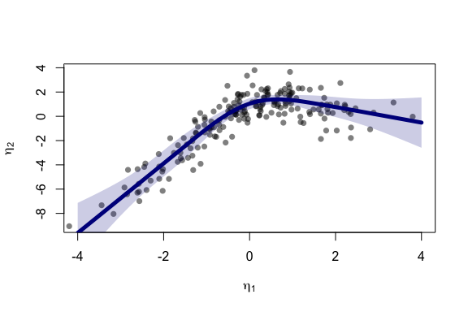

```r
plot(I(eta2-z) ~ eta1, data=d, col=Col("black",0.5), pch=16,
     xlab=expression(eta[1]), ylab=expression(eta[2]), xlim=c(-4,4))
lines(Estimate ~ eta1, data=as.data.frame(p), col="darkblue", lwd=5)
confband(p[,1], lower=p[,4], upper=p[,5], polygon=TRUE,
     border=NA, col=Col("darkblue",0.2))
```

# Cross-validation

```r
m2a <- nonlinear(m2, type="linear", eta2~eta1)
m2b <- nonlinear(m2, type="quadratic", eta2~eta1)
kn1 <- seq(-3,3,length.out=5)
kn2 <- seq(-3,3,length.out=8)
m2c <- nonlinear(m2, type="spline", knots=kn1, eta2~eta1)
m2d <- nonlinear(m2, type="spline", knots=kn2, eta2~eta1)
```

To assess the model fit average RMSE is estimated with 5-fold cross-validation repeated two times

```r
## Scale models in stage 2 to allow for a fair RMSE comparison
d0 <- d
for (i in endogenous(m2))
    d0[,i] <- scale(d0[,i],center=TRUE,scale=TRUE)
## Repeated 5-fold cross-validation:
ff <- lapply(list(linear=m2a,quadratic=m2b,spline4=m2c,spline6=m2d),
        function(m) function(data,...) twostage(m1,m,data=data,stderr=FALSE,control=list(start=coef(e0),contrain=TRUE)))
fit.cv <- lava:::cv(ff,data=d,K=5,rep=2,mc.cores=parallel::detectCores(),seed=1)
```

```r
summary(fit.cv)
```

```
#>       Length Class  Mode
#> cv    40     -none- numeric
#> call   7     -none- call
#> names  4     -none- character
#> rep    1     -none- numeric
#> folds  1     -none- numeric
```

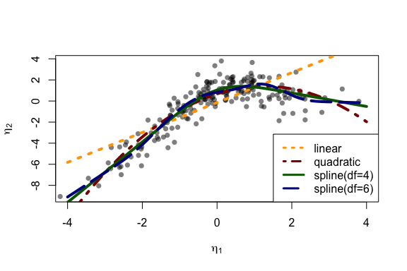

```r
fit <- lapply(list(m2a,m2b,m2c,m2d),
         function(x) {
         e <- twostage(m1,x,data=d)
         pr <- cbind(eta1=newd$eta1,predict(e,newdata=newd$eta1,x=TRUE))
         return(list(estimate=e,predict=as.data.frame(pr)))
         })

plot(I(eta2-z) ~ eta1, data=d, col=Col("black",0.5), pch=16,
     xlab=expression(eta[1]), ylab=expression(eta[2]), xlim=c(-4,4))
col <- c("orange","darkred","darkgreen","darkblue")
lty <- c(3,4,1,5)
for (i in seq_along(fit)) {
    with(fit[[i]]$pr, lines(eta2 ~ eta1, col=col[i], lwd=4, lty=lty[i]))
}
legend("bottomright",
      c("linear","quadratic","spline(df=4)","spline(df=6)"),
      col=col, lty=lty, lwd=3)
```

For convenience, the function `twostageCV` can be used to do the cross-validation (also for choosing the mixture distribution via the ``nmix`` argument, see the section below). For example,

```r
selmod <- twostageCV(m1, m2, data=d, df=2:4, nmix=1:2,
        nfolds=2, rep=1, mc.cores=parallel::detectCores())
```

applies cross-validation (here just 2 folds for simplicity) to select the best splines with degrees of freedom varying from from 1-3 (the linear model is automatically included)

```r
selmod
```

```
#>        Length Class               Mode
#> model1 11     summary.lvm.mixture list
#> AIC1    2     -none-              numeric
#> cv      4     -none-              numeric
#> knots   4     -none-              list
#> model2 11     summary.lvmfit      list
```

# Specification of general functional forms

Next, we show how to specify a general functional relation of multiple different latent or exogenous variables. This is achieved via the `predict.fun` argument. To illustrate this we include interactions between the latent variable $\eta_{1}$ and a dichotomized version of the covariate $z$

```r
d$g <- (d$z<0)*1 ## Group variable
mm1 <- regression(m1, ~g)  # Add grouping variable as exogenous variable (effect specified via 'predict.fun')
mm2 <- regression(m2, eta2~ u1+u2+u1:g+u2:g+z)
pred <- function(mu,var,data,...) {
    cbind("u1"=mu[,1],"u2"=mu[,1]^2+var[1],
      "u1:g"=mu[,1]*data[,"g"],"u2:g"=(mu[,1]^2+var[1])*data[,"g"])
}
ee1 <- twostage(mm1, model2=mm2, data=d, predict.fun=pred)
estimate(ee1,keep="eta2~u",regex=TRUE)
```

```
#>           Estimate Std.Err    2.5%   97.5%  P-value
#> eta2~u1     0.9891  0.3020  0.3971  1.5810 0.001057
#> eta2~u2    -0.3962  0.1443 -0.6791 -0.1133 0.006047
#> eta2~u1:g   0.4487  0.4620 -0.4568  1.3543 0.331409
#> eta2~u2:g   0.0441  0.2166 -0.3804  0.4686 0.838667
```

A formal test show no statistically significant effect of this interaction

```r
summary(estimate(ee1,keep="(:g)", regex=TRUE))
```

```
#> Call: estimate.default(x = ee1, keep = "(:g)", regex = TRUE)
#> ────────────────────────────────────────────────────────────────────────────────
#>           Estimate Std.Err    2.5%  97.5% P-value
#> eta2~u1:g   0.4487  0.4620 -0.4568 1.3543  0.3314
#> eta2~u2:g   0.0441  0.2166 -0.3804 0.4686  0.8387
#>
#>  Null Hypothesis:
#>   [eta2~u1:g] = 0
#>   [eta2~u2:g] = 0
#>
#> chisq = 0.9441, df = 2, p-value = 0.6237
```

# Mixture models

Lastly, we demonstrate how the distributional assumptions of stage 1 model can be relaxed by letting the conditional distribution of the latent variable given covariates follow a Gaussian mixture distribution. The following code explictly defines the parameter constraints of the model by setting the intercept of the first indicator variable, $x_{1}$, to zero and the factor loading parameter of the same variable to one.

```r
m1 <- baptize(m1)  ## Label all parameters
intercept(m1, ~x1+eta1) <- list(0,NA) ## Set intercept of x1 to zero. Remove the label of eta1
regression(m1,x1~eta1) <- 1 ## Factor loading fixed to 1
```

The mixture model may then be estimated using the `mixture` method (note, this requires the `mets` package to be installed), where the Parameter names shared across the different mixture components given in the `list` will be constrained to be identical in the mixture model. Thus, only the intercept of $\eta_{1}$ is allowed to vary between the mixtures.

```r
set.seed(1)
em0 <- mixture(m1, k=2, data=d)
```

To decrease the risk of using a local maximizer of the likelihood we can rerun the estimation with different random starting values

```r
em0 <- NULL
ll <- c()
for (i in 1:5) {
    set.seed(i)
    em <- mixture(m1, k=2, data=d, control=list(trace=0))
    ll <- c(ll,logLik(em))
    if (is.null(em0) || logLik(em0)<tail(ll,1))
    em0 <- em
}
```

```r
summary(em0)
```

```
#> Cluster 1 (n=162, Prior=0.776):
#> --------------------------------------------------
#>                     Estimate Std. Error Z value Pr(>|z|)
#> Measurements:
#>    x1~eta1           1.000
#>    x2~eta1           0.996    0.079     12.541    <1e-12
#>    x3~eta1           1.063    0.084     12.605    <1e-12
#> Regressions:
#>    eta1~z            1.067    0.085     12.510    <1e-12
#> Intercepts:
#>    x1                0.000
#>    x2                0.038    0.099      0.389  0.7
#>    x3               -0.025    0.103     -0.247  0.81
#>    eta1              0.209    0.132      1.590  0.11
#> Residual Variances:
#>    x1                0.985    0.133      7.400
#>    x2                0.972    0.132      7.387
#>    x3                1.013    0.143      7.088
#>    eta1              0.290    0.111      2.610
#>
#> Cluster 2 (n=38, Prior=0.224):
#> --------------------------------------------------
#>                     Estimate Std. Error Z value Pr(>|z|)
#> Measurements:
#>    x1~eta1           1.000
#>    x2~eta1           0.996    0.079     12.541    <1e-12
#>    x3~eta1           1.063    0.084     12.605    <1e-12
#> Regressions:
#>    eta1~z            1.067    0.085     12.510    <1e-12
#> Intercepts:
#>    x1                0.000
#>    x2                0.038    0.099      0.389  0.7
#>    x3               -0.025    0.103     -0.247  0.81
#>    eta1             -1.443    0.259     -5.578  2.4e-08
#> Residual Variances:
#>    x1                0.985    0.133      7.400
#>    x2                0.972    0.132      7.387
#>    x3                1.013    0.143      7.088
#>    eta1              0.290    0.111      2.610
#> --------------------------------------------------
#> AIC= 1959
#> ||score||^2= 8.818e-06
```

Measured by AIC there is a slight improvement in the model fit using the mixture model

```r
e0 <- estimate(m1,data=d)
AIC(e0,em0)
```

```
#>     df  AIC
#> e0  10 1962
#> em0 12 1959
```

The spline model may then be estimated as before with the `two-stage` method

```r
em2 <- twostage(em0,m2,data=d)
em2
```

```
#>                     Estimate Std. Error Z-value  P-value
#> Measurements:
#>    y2~eta2             0.978      0.035  28.237   <1e-12
#>    y3~eta2             1.045      0.035  30.040   <1e-12
#> Regressions:
#>    eta2~z              1.029      0.223   4.607  4.1e-06
#>    eta2~eta1_1         2.804      0.655   4.278  1.9e-05
#>    eta2~eta1_2        -0.022      0.100  -0.225     0.82
#>    eta2~eta1_3        -0.173      0.289  -0.599     0.55
#>    eta2~eta1_4         0.387      0.340   1.138     0.26
#> Intercepts:
#>    y2                 -0.122      0.109  -1.114     0.27
#>    y3                 -0.099      0.105  -0.936     0.35
#>    eta2                2.124      1.666   1.275      0.2
#> Residual Variances:
#>    y1                  1.319      0.177   7.470
#>    y2                  1.097      0.145   7.564
#>    y3                  0.813      0.133   6.135
#>    eta2                1.996      0.283   7.055
```

In this example the results are very similar to the Gaussian model:

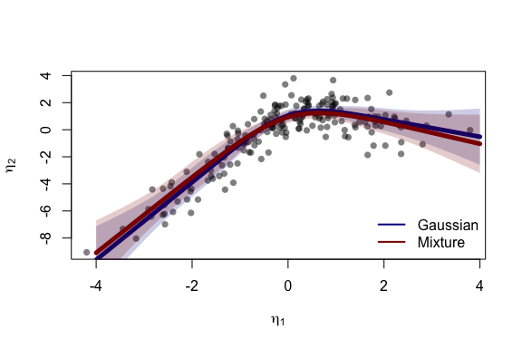

```r
plot(I(eta2-z) ~ eta1, data=d, col=Col("black",0.5), pch=16,
     xlab=expression(eta[1]), ylab=expression(eta[2]))

lines(Estimate ~ eta1, data=as.data.frame(p), col="darkblue", lwd=5)
confband(p[,1], lower=p[,4], upper=p[,5], polygon=TRUE,
     border=NA, col=Col("darkblue",0.2))

pm <- cbind(eta1=newd$eta1,
        estimate(em2, f=function(p) predict(e2,p=p,newdata=newd))$coefmat)
lines(Estimate ~ eta1, data=as.data.frame(pm), col="darkred", lwd=5)
confband(pm[,1], lower=pm[,4], upper=pm[,5], polygon=TRUE,
     border=NA, col=Col("darkred",0.2))
legend("bottomright", c("Gaussian","Mixture"),
       col=c("darkblue","darkred"), lwd=2, bty="n")
```

# Bibliography

Holst, K. K., and E. Budtz-Jørgensen. 2013. “Linear Latent Variable Models: The Lava-Package.” *Computational Statistics* 28 (4): 1385–1452. https://doi.org/10.1007/s00180-012-0344-y.

Holst, Klaus Kähler, and Esben Budtz-Jørgensen. 2020. “A Two-Stage Estimation Procedure for Non-Linear Structural Equation Models.” *Biostatistics* (in press). https://doi.org/10.1093/biostatistics/kxy082.